# Hand Written Number Reader Project

### First we must import TensorFlow and matplotlib.

```python
import tensorflow as tf
import matplotlib.pyplot as plt
tf.__version__
```

```
'2.0.0'
```

### Now that we have imported the necessary libraries let's begin by setting up our train and test sets.

```python
# Setting up our train and test sets
mnist = tf.keras.datasets.mnist  # images of handwritten images 0-9
(x_train, y_train), (x_test, y_test) = mnist.load_data()
x_train = tf.keras.utils.normalize(x_train, axis=1)
x_test = tf.keras.utils.normalize(x_test, axis=1)
```

### Next let's choose which model and how many layers to use for building our network.

```python
# Indicate which model to use and how many layers in our network
model = tf.keras.models.Sequential()
model.add(tf.keras.layers.Flatten())
model.add(tf.keras.layers.Dense(128, activation=tf.nn.relu))
model.add(tf.keras.layers.Dense(128, activation=tf.nn.relu))
model.add(tf.keras.layers.Dense(10, activation=tf.nn.softmax))
```

### Now that we have our neural network ready lets compile it and run some simulations.

```python
# Compile our model and run epochs
model.compile(optimizer='adam',
             loss='sparse_categorical_crossentropy',
             metrics=['accuracy'])
model.fit(x_train, y_train, epochs=5)
```

```
Train on 60000 samples
```

```
<tensorflow.python.keras.callbacks.History at 0x132b70197b8>
```

### Before proceeding let's double check our data by printing what should be an image of a handwritten number

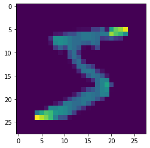

```python
# Check our train data
plt.imshow(x_train[0])
```

```python
model.save('written_number_reader.model')
```

```
INFO:tensorflow:Assets written to: written_number_reader.model\assets
```

```python
new_model = tf.keras.models.load_model('written_number_reader.model')
```

### Now before we make any predictions using our model we have to indicate which set we want our predicitons to be based on.

```python
# Indicate which set used make predictions
predictions = new_model.predict([x_test])
```

### Finally let's use our model to tell us which number is written in the image of our dataset

```python
# Check our Answer
import numpy as np
print(np.argmax(predictions[72]))
```

```
2
```

### According to our model the image in our dataset is a 2 so now let's check the image to see if it is right.

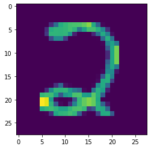

```python
plt.imshow(x_test[72])
```

## Perfect! As you can see the image is the number 2 and our model correctly labeled it as such.